# Práctica 0. FMAD 2021-2022

ICAI. Master en Big Data. Fundamentos Matemáticos del Análisis de Datos (FMAD).

Elósegui Ana

Curso 2021-22. Última actualización: 2021-09-17

# Ejercicio 0 (ejemplo).

**Enunciado:** Usa la función `seq` de R para fabricar un vector `v` con los múltiplos de 3 del 0 al 300. Muestra los primeros 20 elementos de `v` usando `head` y calcula:

- la suma del vector `v`,
- su media,
- y su longitud.

**Respuesta:**

```r
v = seq(from = 0, to = 300, by = 3)
head(v, 20)
```

```
##  [1]  0  3  6  9 12 15 18 21 24 27 30 33 36 39 42 45 48 51 54 57
```

Suma de `v`

```r
sum(v)
```

```
## [1] 15150
```

Media:

```r
mean(v)
```

```
## [1] 150
```

Longitud:

```r
length(v)
```

```
## [1] 101
```

# Preliminares

```r
library(dplyr)
library(ggplot2)
library(tidyverse)
library(haven)
```

# Ejercicio 1

Se crea el vector dado_honesto y se imprimen los 10 primeros valores.

```r
dado_honesto <- sample(1:6, 100, replace=TRUE)
head(dado_honesto, 10)
```

```
##  [1] 3 5 2 2 3 6 5 2 3 4
```

Se calculan la frecuencias absolutas de cada valor utilizando dos funciones diferentes.

```r
freqabs1 <- table(dado_honesto)
freqabs1
```

```
## dado_honesto
##  1  2  3  4  5  6
## 16 18 15 18 14 19
```

```r
freqabs2 <- as.data.frame(dado_honesto)
freqabs2 %>%
  count(dado_honesto)
```

```
##   dado_honesto  n
## 1            1 16
## 2            2 18
## 3            3 15
## 4            4 18
## 5            5 14
## 6            6 19
```

Se calculan la frecuencias relativas de cada valor.

```r
freqabs2 %>%
  count(dado_honesto) %>%
  mutate(dado_honesto, relFreq = prop.table(n), n=NULL)
```

```
##   dado_honesto relFreq
## 1            1    0.16
## 2            2    0.18
## 3            3    0.15
## 4            4    0.18
## 5            5    0.14
## 6            6    0.19
```

# Ejercicio 2

Se crea el vector dado_cargado y se imprimen los 10 primeros valores.

```r
dado_cargado <- sample(1:6, 100, replace=TRUE, prob=c(1/7, 1/7, 1/7, 1/7, 1/7, 2/7))
head(dado_cargado, 10)
```

```
##  [1] 5 3 5 2 1 3 1 1 6 3
```

Se calculan la frecuencias absolutas de cada valor.

```r
freqabsc <- as.data.frame(dado_cargado)
freqabsc %>%
  count(dado_cargado)
```

```
##   dado_cargado  n
## 1            1 17
## 2            2 16
## 3            3 20
## 4            4 12
## 5            5 12
## 6            6 23
```

Se calculan la frecuencias relativas de cada valor. Como se ha podido observar en la tabla anterior es más probable que salga un 6 que otro número.

```r
freqabsc %>%
  count(dado_cargado) %>%
  mutate(dado_cargado, relFreq = prop.table(n), n=NULL)
```

```
##   dado_cargado relFreq
## 1            1    0.17
## 2            2    0.16
## 3            3    0.20
## 4            4    0.12
## 5            5    0.12
## 6            6    0.23
```

# Ejercicio 3

Se crean los 3 vectores diferentes con los valores indicados.

```r
v1=rep(seq(1,4), times=4)
v1
```

```
##  [1] 1 2 3 4 1 2 3 4 1 2 3 4 1 2 3 4
```

```r
v2=rep(seq(1,5), times=c(1,2,3,4,5))
v2
```

```
##  [1] 1 2 2 3 3 3 4 4 4 4 5 5 5 5 5
```

```r
v3=rep(seq(1,4), times=5)
v3
```

```
##  [1] 1 2 3 4 1 2 3 4 1 2 3 4 1 2 3 4 1 2 3 4
```

# Ejercicio 4

Se crea la tabla mpg2 con los parámetros definidos.

```r
mpg2 <- mpg %>%
  filter(class == 'pickup') %>%
  select(starts_with('C'))
mpg2
```

```
## # A tibble: 33 x 3
##      cyl   cty class
##    <int> <int> <chr>
##  1     6    15 pickup
##  2     6    14 pickup
##  3     6    13 pickup
##  4     6    14 pickup
##  5     8    14 pickup
##  6     8    14 pickup
##  7     8     9 pickup
##  8     8    11 pickup
##  9     8    11 pickup
## 10     8    12 pickup
## # ... with 23 more rows
```

# Ejercicio 5

```r
census <- read_dta("data/census.dta")
census
```

```
## # A tibble: 50 x 12
##    state        region    pop poplt5 pop5_17 pop18p pop65p popurban medage  death
##    <chr>       <dbl+l>  <dbl>  <dbl>   <dbl>  <dbl>  <dbl>    <dbl>  <dbl>  <dbl>
##  1 Alabama     3 [Sou~ 3.89e6 2.96e5  865836 2.73e6 4.40e5  2337713   29.3  35305
##  2 Alaska      4 [Wes~ 4.02e5 3.89e4   91796 2.71e5 1.15e4   258567   26.1   1604
##  3 Arizona     4 [Wes~ 2.72e6 2.14e5  577604 1.93e6 3.07e5  2278728   29.2  21226
##  4 Arkansas    3 [Sou~ 2.29e6 1.76e5  495782 1.62e6 3.12e5  1179556   30.6  22676
##  5 California  4 [Wes~ 2.37e7 1.71e6 4680558 1.73e7 2.41e6 21607606   29.9 186428
##  6 Colorado    4 [Wes~ 2.89e6 2.16e5  592318 2.08e6 2.47e5  2329869   28.6  18925
##  7 Connecticut 1 [NE]  3.11e6 1.85e5  637731 2.28e6 3.65e5  2449774   32    26005
##  8 Delaware    3 [Sou~ 5.94e5 4.12e4  125444 4.28e5 5.92e4   419819   29.8   5123
##  9 Florida     3 [Sou~ 9.75e6 5.70e5 1789412 7.39e6 1.69e6  8212385   34.7 104190
## 10 Georgia     3 [Sou~ 5.46e6 4.15e5 1231195 3.82e6 5.17e5  3409081   28.7  44230
## # ... with 40 more rows, and 2 more variables: marriage <dbl>, divorce <dbl>
```

**5.1**

Se calculan las poblaciones totales por región.

```r
pobreg <- census %>%
  group_by(region) %>%
  summarise(sumpop=sum(pop))
pobreg
```

```
## # A tibble: 4 x 2
##        region   sumpop
##     <dbl+lbl>    <dbl>
## 1 1 [NE]      49135283
## 2 2 [N Cntrl] 58865670
## 3 3 [South]   74734029
## 4 4 [West]    43172490
```

**5.2**

Se grafican los resultados obtenidos en la tabla anterior.

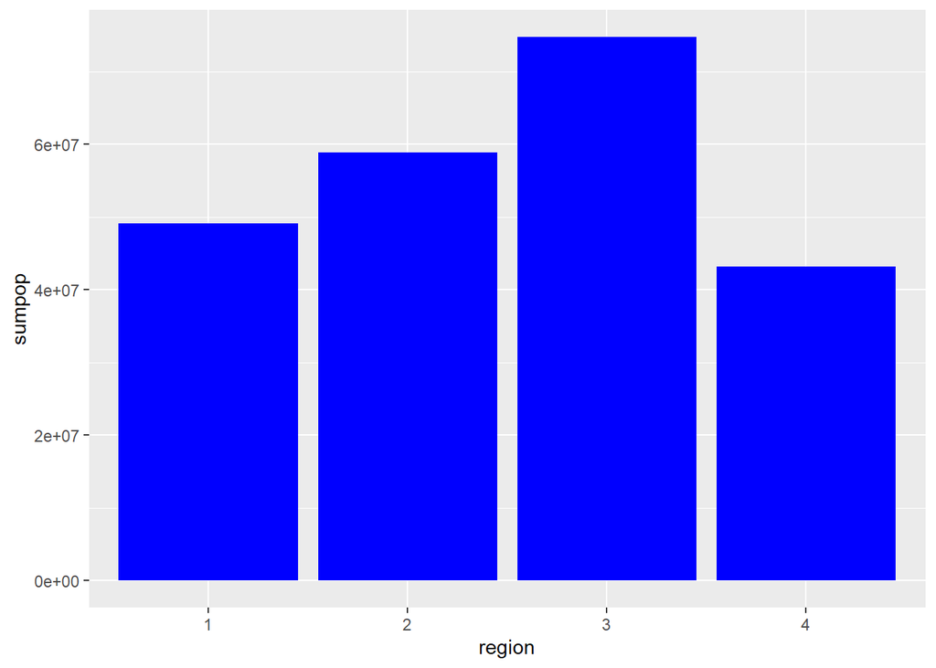

```r
pobreg$region <- as.factor(pobreg$region)
ggplot(data=pobreg, aes(x=region, y=sumpop)) + geom_bar(stat='identity', fill='blue')
```

**5.3**

Se muestra una tabla ordenando los estados según su población total, de más poblado a menos poblado.

```r
pobstate <- census %>%
  arrange(desc(pop))
pobstate
```

```
## # A tibble: 50 x 12
##    state       region    pop poplt5 pop5_17 pop18p pop65p popurban medage  death
##    <chr>    <dbl+lbl>  <dbl>  <dbl>   <dbl>  <dbl>  <dbl>    <dbl>  <dbl>  <dbl>
##  1 Califor~ 4 [West]  2.37e7 1.71e6 4680558 1.73e7 2.41e6 21607606   29.9 186428
##  2 New York 1 [NE]    1.76e7 1.14e6 3551938 1.29e7 2.16e6 14858068   31.9 171769
##  3 Texas    3 [South] 1.42e7 1.17e6 3137045 9.92e6 1.37e6 11333017   28.2 108019
##  4 Pennsyl~ 1 [NE]    1.19e7 7.47e5 2375838 8.74e6 1.53e6  8220851   32.1 123261
##  5 Illinois 2 [N Cnt~ 1.14e7 8.42e5 2400796 8.18e6 1.26e6  9518039   29.9 102230
##  6 Ohio     2 [N Cnt~ 1.08e7 7.87e5 2307170 7.70e6 1.17e6  7918259   29.9  98268
##  7 Florida  3 [South] 9.75e6 5.70e5 1789412 7.39e6 1.69e6  8212385   34.7 104190
##  8 Michigan 2 [N Cnt~ 9.26e6 6.85e5 2066873 6.51e6 9.12e5  6551551   28.8  75102
##  9 New Jer~ 1 [NE]    7.36e6 4.63e5 1527572 5.37e6 8.60e5  6557377   32.2  68762
## 10 N. Caro~ 3 [South] 5.88e6 4.04e5 1253659 4.22e6 6.03e5  2822852   29.6  48426
## # ... with 40 more rows, and 2 more variables: marriage <dbl>, divorce <dbl>
```

**5.4**

Se calcula la tasa de divorcios por estado.

```r
tdiv <- census %>%
  select(state, divorce, marriage) %>%
  group_by(state) %>%
  mutate(tasa=divorce/marriage)
tdiv
```

```
## # A tibble: 50 x 4
## # Groups:   state [50]
##    state       divorce marriage  tasa
##    <chr>         <dbl>    <dbl> <dbl>
##  1 Alabama       26745    49018 0.546
##  2 Alaska         3517     5361 0.656
##  3 Arizona       19908    30223 0.659
##  4 Arkansas      15882    26513 0.599
##  5 California   133541   210864 0.633
##  6 Colorado      18571    34917 0.532
##  7 Connecticut   13488    26048 0.518
##  8 Delaware       2313     4437 0.521
##  9 Florida       71579   108344 0.661
## 10 Georgia       34743    70638 0.492
## # ... with 40 more rows
```

**5.5**

Se calculan la edad media de la población y el porcentaje de personas mayores respecto a la población total por estado.

```r
pobage <- census %>%
  select(state, medage) %>%
  arrange(desc(medage)) %>%
  mutate(pobold=census$pop65p/census$pop)
head(pobage, 10)
```

```
## # A tibble: 10 x 3
##    state         medage pobold
##    <chr>          <dbl>  <dbl>
##  1 Florida         34.7 0.113
##  2 New Jersey      32.2 0.0287
##  3 Pennsylvania    32.1 0.113
##  4 Connecticut     32   0.137
##  5 New York        31.9 0.102
##  6 Rhode Island    31.8 0.0856
##  7 Massachusetts   31.2 0.117
##  8 Missouri        30.9 0.0996
##  9 Arkansas        30.6 0.173
## 10 Maine           30.4 0.0946
```

**5.6**

Se grafican los valores de la media de edad de los estados y la curva de densidad de esta variable.

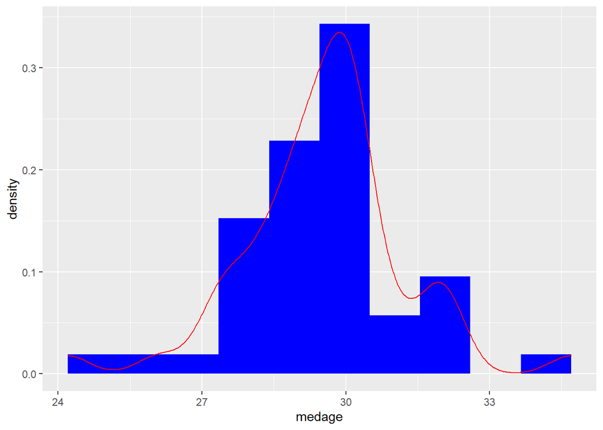

```r
int <- seq(min(census$medage), max(census$medage), length.out=11)
ggplot(data=census, aes(x=medage))+ geom_histogram(aes(y=stat(density)), breaks=int, fill="blue")+ geom_density(color="red")
```